# TO 628 Final Team Project

Yongsoo Shin

Due on April 20, 2020

# 1 Class Topics

Topics learned so far:

1. Linear Regression
2. Logistic Regression
3. KNN
4. ANN
5. SVM
6. Decision Trees
7. Random Forest

# 2 Read Me

This document serves as a subsidary document to a group project for which city bike data in NYC is used. The purpose of this document is to share analysis of the influence of weather to the bike usage.

Here, city bike data from 2019 will be used for the analysis. Specifically, 5% of the entire 2019 data was extracted, and the extracted data was further separated into test (20%) and train (80%). Particularily, the train data will be used to model the usage of the entire year per month, and test data will be used to assess the accuracy of the chosen model with the best fit.

Ultimately, the findings will be used to identify the relationship between weather and bike usage and predict the bike usage based on chosen parameters (e.g. precipitation amount).

# 3 Dataset Explanation

- City bike data in NYC
- Each dataset is comprised of 1 month trip data
  - Data from 12 months of 2019 have been combined
  - The 5% of combined dataset has been divided into train (80%) and test (20%) datasets.
- Variables (City bike):
  - trip duration (sec)
  - start time (year, month, day, time)
  - stop time (year, month, day, time)
  - start station (id, lat/long)
  - end station (id, lat/long)
  - bike id
  - user type
    - customer (24 hr vs 3 day)
    - subscriber (annual)
  - birth year
  - gender (0, 1, 2 = unknown, male, female)
- Variables (Weather):
  - TMIN (minimum temperature in C)
  - TMAX (maximum temperature in C)
  - Average wind speed
  - PRCP (mm)
  - SNOW (mm)

# 4 Load Datasets

```r
#load train dataset
traindata = read.csv("bike_weather_train_clean.csv")

#load test dataset
testdata = read.csv("bike_weather_test_clean.csv")

#load data - station information
#station_info = read.csv("station_information.csv")
```

# 5 Join Station Info and Train/Test data

Station Info is retrieved from the website directly, providing capacity of each station

```r
#explore and compare station information
#colnames(station_info)
#length(unique(station_info$station_id))
#length(unique(traindata$start.station.id))

#data of interest: station_id and capacity
#traindata$start.station.capacity = NA #initialize
#traindata$end.station.capacity = NA #initialize
#testdata$start.station.capacity = NA #initialize
#testdata$end.station.capacity = NA #initialize
#traindata_start_station_id_with_unknown_capacity = 0 #initialize
#traindata_end_station_id_with_unknown_capacity = 0 #initialize
#testdata_start_station_id_with_unknown_capacity = 0 #initialize
#testdata_end_station_id_with_unknown_capacity = 0 #initialize
```

```r
#for (i in 1:nrow(station_info))
#{
#   train_rows_with_start_station_id = which(traindata$start.station.id == station_info$station_id[i])
#   traindata$start.station.capacity[train_rows_with_start_station_id] = station_info$station_id[i]
#   test_rows_with_start_station_id = which(testdata$start.station.id == station_info$station_id[i])
#   testdata$start.station.capacity[test_rows_with_start_station_id] = station_info$station_id[i]
#
#   train_rows_with_end_station_id = which(traindata$end.station.id == station_info$station_id[i])
#   traindata$end.station.capacity[train_rows_with_end_station_id] = station_info$station_id[i]
#   test_rows_with_end_station_id = which(testdata$end.station.id == station_info$station_id[i])
#   testdata$end.station.capacity[test_rows_with_end_station_id] = station_info$station_id[i]
#
#   if (length(train_rows_with_start_station_id) == 0)
#   {
#     if (traindata_start_station_id_with_unknown_capacity == 0)
#     {
#       traindata_start_station_id_with_unknown_capacity = station_info$station_id[i]
#     }
#     else if (traindata_start_station_id_with_unknown_capacity != 0)
#     {
#       traindata_start_station_id_with_unknown_capacity[length(traindata_start_station_id_with_unknown_capacity)+1] = station_info$station_id[i]
#     }
#   }
#
#   if (length(train_rows_with_end_station_id) == 0)
#   {
#     if (traindata_end_station_id_with_unknown_capacity == 0)
#     {
#       traindata_end_station_id_with_unknown_capacity = station_info$station_id[i]
#     }
#     else if (traindata_end_station_id_with_unknown_capacity != 0)
#     {
#       traindata_end_station_id_with_unknown_capacity[length(traindata_end_station_id_with_unknown_capacity)+1] = station_info$station_id[i]
#     }
#   }
#
#   if (length(test_rows_with_start_station_id) == 0)
# {
#   if (testdata_start_station_id_with_unknown_capacity == 0)
#   {
#     testdata_start_station_id_with_unknown_capacity = station_info$station_id[i]
#   }
#   else if (testdata_start_station_id_with_unknown_capacity != 0)
#   {
#     testdata_start_station_id_with_unknown_capacity[length(testdata_start_station_id_with_unknown_capacity)+1] = station_info$station_id[i]
#   }
# }
#
# if (length(test_rows_with_end_station_id) == 0)
# {
#   if (testdata_end_station_id_with_unknown_capacity == 0)
#   {
#     testdata_end_station_id_with_unknown_capacity = station_info$station_id[i]
#   }
#   else if (testdata_end_station_id_with_unknown_capacity != 0)
#   {
#     testdata_end_station_id_with_unknown_capacity[length(testdata_end_station_id_with_unknown_capacity)+1] = station_info$station_id[i]
#   }
# }
#
# }
#
```

# 6 Clean up Datasets

Ensure that no additional clean up is needed after train and test datasets are extracted from the entire 2019 usage.

```r
#train dataset
traindata$X.1 = NULL
traindata$X = NULL
traindata$start_year = NULL
traindata$starttime = NULL
traindata$stop_year = NULL
traindata$stoptime = NULL
traindata$stoptime = NULL
traindata$Date = NULL
traindata$start.station.id = as.integer(traindata$start.station.id)
traindata$end.station.id = as.integer(traindata$end.station.id)
colnames(traindata)
```

```
##  [1] "start_mth"               "start_day"
##  [3] "tripduration"            "start.station.id"
##  [5] "start.station.name"      "start.station.latitude"
##  [7] "start.station.longitude" "end.station.id"
##  [9] "end.station.name"        "end.station.latitude"
## [11] "end.station.longitude"   "bikeid"
## [13] "usertype"                "birth.year"
## [15] "gender"                  "start_hr"
## [17] "start_min"               "stop_mth"
## [19] "stop_day"                "stop_hr"
## [21] "stop_min"                "TMIN...C."
## [23] "TMAX...C."               "Ave.Wind.Speed"
## [25] "PRCP..mm."               "SNOW..mm."
```

```r
str(traindata)
```

```
## 'data.frame':    815935 obs. of  26 variables:
##  $ start_mth              : int  1 1 1 1 1 1 1 1 1 1 ...
##  $ start_day              : int  1 1 1 1 1 1 1 1 1 1 ...
##  $ tripduration           : int  1378 820 1287 474 192 1878 210 1074 610 795 ...
##  $ start.station.id       : int  749 792 89 397 199 200 778 784 206 88 ...
##  $ start.station.name     : Factor w/ 831 levels "1 Ave & E 110 St",..: 5 491 184 523 784 786 348 751 269 570 ...
##  $ start.station.latitude : num  40.8 40.7 40.7 40.7 40.8 ...
##  $ start.station.longitude: num  -74 -74 -74 -74 -74 ...
##  $ end.station.id         : int  259 498 369 423 728 213 795 719 807 712 ...
##  $ end.station.name       : Factor w/ 832 levels "1 Ave & E 110 St",..: 417 166 275 340 784 794 2 437 778 810 ...
##  $ end.station.latitude   : num  40.8 40.7 40.7 40.7 40.8 ...
##  $ end.station.longitude  : num  -73.9 -74 -74 -74 -74 ...
##  $ bikeid                 : int  21541 28895 34748 19480 34022 33848 25712 15782 31168 35252 ...
##  $ usertype               : Factor w/ 2 levels "Customer","Subscriber": 2 2 2 2 2 2 2 2 2 2 ...
##  $ birth.year             : int  1938 1993 1973 1991 1959 1962 1990 1986 1989 1969 ...
##  $ gender                 : int  1 2 1 2 1 1 1 1 1 0 ...
##  $ start_hr               : int  12 11 17 17 15 10 14 13 17 16 ...
##  $ start_min              : int  39 41 59 42 52 24 42 36 13 19 ...
##  $ stop_mth               : int  1 1 1 1 1 1 1 1 1 1 ...
##  $ stop_day               : int  1 1 1 1 1 1 1 1 1 1 ...
##  $ stop_hr                : int  13 11 18 17 15 10 14 13 17 16 ...
##  $ stop_min               : int  2 55 21 50 55 55 45 54 23 32 ...
##  $ TMIN...C.              : num  3.9 3.9 3.9 3.9 3.9 3.9 3.9 3.9 3.9 3.9 ...
##  $ TMAX...C.              : num  14.4 14.4 14.4 14.4 14.4 14.4 14.4 14.4 14.4 14.4 ...
##  $ Ave.Wind.Speed         : num  0 0 0 0 0 0 0 0 0 0 ...
##  $ PRCP..mm.              : num  1.5 1.5 1.5 1.5 1.5 1.5 1.5 1.5 1.5 1.5 ...
##  $ SNOW..mm.              : num  0 0 0 0 0 0 0 0 0 0 ...
```

```r
summary(traindata)
```

```
##    start_mth        start_day      tripduration     start.station.id
##  Min.   : 1.000   Min.   : 1.00   Min.   :   61.0   Min.   :  1.0
##  1st Qu.: 5.000   1st Qu.: 8.00   1st Qu.:  362.0   1st Qu.:190.0
##  Median : 7.000   Median :15.00   Median :  615.0   Median :434.0
##  Mean   : 6.833   Mean   :15.63   Mean   :  832.8   Mean   :442.8
##  3rd Qu.: 9.000   3rd Qu.:23.00   3rd Qu.: 1076.0   3rd Qu.:733.0
##  Max.   :12.000   Max.   :31.00   Max.   :17862.0   Max.   :828.0
##
##              start.station.name start.station.latitude start.station.longitude
##  Pershing Square North:  6281   Min.   :40.66          Min.   :-74.03
##  E 17 St & Broadway   :  4896   1st Qu.:40.72          1st Qu.:-74.00
##  8 Ave & W 31 St      :  4806   Median :40.74          Median :-73.99
##  Broadway & E 22 St   :  4526   Mean   :40.74          Mean   :-73.98
##  Broadway & E 14 St   :  4522   3rd Qu.:40.76          3rd Qu.:-73.97
##  W 21 St & 6 Ave      :  4461   Max.   :40.86          Max.   :-73.88
##  (Other)              :786443
##  end.station.id               end.station.name  end.station.latitude
##  Min.   :  1.0   Pershing Square North:  6120   Min.   :40.66
##  1st Qu.:189.0   E 17 St & Broadway   :  5069   1st Qu.:40.72
##  Median :439.0   Broadway & E 22 St   :  4931   Median :40.74
##  Mean   :444.5   West St & Chambers St:  4662   Mean   :40.74
##  3rd Qu.:734.0   8 Ave & W 31 St      :  4650   3rd Qu.:40.76
##  Max.   :829.0   Broadway & E 14 St   :  4560   Max.   :40.86
##                  (Other)              :785943
##  end.station.longitude     bikeid            usertype        birth.year
##  Min.   :-74.04        Min.   :14529   Customer  :113649   Min.   :1921
##  1st Qu.:-74.00        1st Qu.:25349   Subscriber:702286   1st Qu.:1970
##  Median :-73.99        Median :30910                       Median :1983
##  Mean   :-73.98        Mean   :29663                       Mean   :1980
##  3rd Qu.:-73.97        3rd Qu.:35038                       3rd Qu.:1990
##  Max.   :-73.88        Max.   :42046                       Max.   :2003
##
##      gender         start_hr       start_min       stop_mth
##  Min.   :0.000   Min.   : 0.00   Min.   : 0.0   Min.   : 1.000
##  1st Qu.:1.000   1st Qu.:10.00   1st Qu.:14.0   1st Qu.: 5.000
##  Median :1.000   Median :14.00   Median :30.0   Median : 7.000
##  Mean   :1.166   Mean   :13.88   Mean   :29.5   Mean   : 6.834
##  3rd Qu.:1.000   3rd Qu.:18.00   3rd Qu.:44.0   3rd Qu.: 9.000
##  Max.   :2.000   Max.   :23.00   Max.   :59.0   Max.   :12.000
##
##     stop_day        stop_hr         stop_min       TMIN...C.
##  Min.   : 1.00   Min.   : 0.00   Min.   : 0.00   Min.   :-16.60
##  1st Qu.: 8.00   1st Qu.:10.00   1st Qu.:15.00   1st Qu.:  5.60
##  Median :15.00   Median :15.00   Median :30.00   Median : 13.30
##  Mean   :15.63   Mean   :14.03   Mean   :29.82   Mean   : 12.07
##  3rd Qu.:23.00   3rd Qu.:18.00   3rd Qu.:45.00   3rd Qu.: 19.40
##  Max.   :31.00   Max.   :23.00   Max.   :59.00   Max.   : 27.80
##
##    TMAX...C.     Ave.Wind.Speed    PRCP..mm.        SNOW..mm.
##  Min.   :-9.90   Min.   :0.000   Min.   : 0.000   Min.   : 0.00000
##  1st Qu.:13.90   1st Qu.:1.200   1st Qu.: 0.000   1st Qu.: 0.00000
##  Median :21.70   Median :1.600   Median : 0.000   Median : 0.00000
##  Mean   :20.14   Mean   :1.747   Mean   : 2.672   Mean   : 0.04926
##  3rd Qu.:27.20   3rd Qu.:2.300   3rd Qu.: 1.000   3rd Qu.: 0.00000
##  Max.   :35.00   Max.   :5.700   Max.   :46.500   Max.   :10.20000
##
```

```r
#test dataset
testdata$X.1 = NULL
testdata$X = NULL
testdata$start_year = NULL
testdata$starttime = NULL
testdata$stop_year = NULL
testdata$stoptime = NULL
testdata$stoptime = NULL
testdata$Date = NULL
testdata$start.station.id = as.integer(testdata$start.station.id)
testdata$end.station.id = as.integer(testdata$end.station.id)
colnames(testdata)
```

```
##  [1] "start_mth"               "start_day"
##  [3] "tripduration"            "start.station.id"
##  [5] "start.station.name"      "start.station.latitude"
##  [7] "start.station.longitude" "end.station.id"
##  [9] "end.station.name"        "end.station.latitude"
## [11] "end.station.longitude"   "bikeid"
## [13] "usertype"                "birth.year"
## [15] "gender"                  "start_hr"
## [17] "start_min"               "stop_mth"
## [19] "stop_day"                "stop_hr"
## [21] "stop_min"                "TMIN...C."
## [23] "TMAX...C."               "Ave.Wind.Speed"
## [25] "PRCP..mm."               "SNOW..mm."
```

```r
str(testdata)
```

```
## 'data.frame':    203983 obs. of  26 variables:
##  $ start_mth              : int  1 1 1 1 1 1 1 1 1 1 ...
##  $ start_day              : int  1 1 1 1 1 1 1 1 1 1 ...
##  $ tripduration           : int  530 563 2026 1750 575 1385 187 3798 606 1119 ...
##  $ start.station.id       : int  495 466 285 3159 3499 380 3502 427 3429 2006 ...
##  $ start.station.name     : Factor w/ 830 levels "1 Ave & E 110 St",..: 772 748 186 785 29 760 542 205 485 234 ...
##  $ start.station.latitude : num  40.8 40.7 40.7 40.8 40.8 ...
##  $ start.station.longitude: num  -74 -74 -74 -74 -73.9 ...
##  $ end.station.id         : int  3158 498 445 3508 3499 518 3387 3489 120 3282 ...
##  $ end.station.name       : Factor w/ 830 levels "1 Ave & E 110 St",..: 783 193 312 675 29 361 318 464 541 113 ...
##  $ end.station.latitude   : num  40.8 40.7 40.7 40.8 40.8 ...
##  $ end.station.longitude  : num  -74 -74 -74 -74 -73.9 ...
##  $ bikeid                 : int  33909 33809 33554 35660 33419 21215 31143 16992 35077 26573 ...
##  $ usertype               : Factor w/ 2 levels "Customer","Subscriber": 2 1 2 2 2 2 2 1 2 1 ...
##  $ birth.year             : int  1969 1991 1950 1965 1966 1978 1989 1969 1990 1983 ...
##  $ gender                 : int  1 2 1 1 2 1 1 0 2 2 ...
##  $ start_hr               : int  9 15 22 11 6 9 11 13 16 16 ...
##  $ start_min              : int  46 28 9 42 3 27 8 17 20 31 ...
##  $ stop_mth               : int  1 1 1 1 1 1 1 1 1 1 ...
##  $ stop_day               : int  1 1 1 1 1 1 1 1 1 1 ...
##  $ stop_hr                : int  9 15 22 12 6 9 11 14 16 16 ...
##  $ stop_min               : int  55 38 43 11 13 50 12 20 31 50 ...
##  $ TMIN...C.              : num  3.9 3.9 3.9 3.9 3.9 3.9 3.9 3.9 3.9 3.9 ...
##  $ TMAX...C.              : num  14.4 14.4 14.4 14.4 14.4 14.4 14.4 14.4 14.4 14.4 ...
##  $ Ave.Wind.Speed         : num  0 0 0 0 0 0 0 0 0 0 ...
##  $ PRCP..mm.              : num  1.5 1.5 1.5 1.5 1.5 1.5 1.5 1.5 1.5 1.5 ...
##  $ SNOW..mm.              : num  0 0 0 0 0 0 0 0 0 0 ...
```

```r
summary(testdata)
```

```
##    start_mth        start_day      tripduration     start.station.id
##  Min.   : 1.000   Min.   : 1.00   Min.   :   61.0   Min.   :  72
##  1st Qu.: 5.000   1st Qu.: 8.00   1st Qu.:  360.0   1st Qu.: 380
##  Median : 7.000   Median :15.00   Median :  613.0   Median : 513
##  Mean   : 6.829   Mean   :15.63   Mean   :  829.2   Mean   :1656
##  3rd Qu.: 9.000   3rd Qu.:23.00   3rd Qu.: 1071.0   3rd Qu.:3293
##  Max.   :12.000   Max.   :31.00   Max.   :17539.0   Max.   :3810
##
##              start.station.name start.station.latitude start.station.longitude
##  Pershing Square North:  1529   Min.   :40.66          Min.   :-74.03
##  8 Ave & W 31 St      :  1253   1st Qu.:40.72          1st Qu.:-74.00
##  Broadway & E 22 St   :  1174   Median :40.74          Median :-73.99
##  E 17 St & Broadway   :  1153   Mean   :40.74          Mean   :-73.98
##  Broadway & E 14 St   :  1123   3rd Qu.:40.76          3rd Qu.:-73.97
##  W 21 St & 6 Ave      :  1083   Max.   :40.81          Max.   :-73.91
##  (Other)              :196668
##  end.station.id              end.station.name  end.station.latitude
##  Min.   :  72   Pershing Square North:  1559   Min.   :40.66
##  1st Qu.: 379   E 17 St & Broadway   :  1227   1st Qu.:40.72
##  Median : 509   8 Ave & W 31 St      :  1217   Median :40.74
##  Mean   :1646   Broadway & E 22 St   :  1191   Mean   :40.74
##  3rd Qu.:3292   Broadway & E 14 St   :  1163   3rd Qu.:40.76
##  Max.   :3810   West St & Chambers St:  1148   Max.   :40.81
##                 (Other)              :196478
##  end.station.longitude     bikeid            usertype        birth.year
##  Min.   :-74.03        Min.   :14529   Customer  : 28310   Min.   :1921
##  1st Qu.:-74.00        1st Qu.:25360   Subscriber:175673   1st Qu.:1970
##  Median :-73.99        Median :30907                       Median :1983
##  Mean   :-73.98        Mean   :29665                       Mean   :1980
##  3rd Qu.:-73.97        3rd Qu.:35033                       3rd Qu.:1990
##  Max.   :-73.91        Max.   :42046                       Max.   :2003
##
##      gender         start_hr       start_min       stop_mth
##  Min.   :0.000   Min.   : 0.00   Min.   : 0.0   Min.   : 1.000
##  1st Qu.:1.000   1st Qu.:10.00   1st Qu.:14.0   1st Qu.: 5.000
##  Median :1.000   Median :14.00   Median :29.0   Median : 7.000
##  Mean   :1.162   Mean   :13.87   Mean   :29.5   Mean   : 6.829
##  3rd Qu.:1.000   3rd Qu.:18.00   3rd Qu.:44.0   3rd Qu.: 9.000
##  Max.   :2.000   Max.   :23.00   Max.   :59.0   Max.   :12.000
##
##     stop_day        stop_hr         stop_min       TMIN...C.
##  Min.   : 1.00   Min.   : 0.00   Min.   : 0.00   Min.   :-16.60
##  1st Qu.: 8.00   1st Qu.:10.00   1st Qu.:15.00   1st Qu.:  5.60
##  Median :15.00   Median :15.00   Median :30.00   Median : 13.30
##  Mean   :15.63   Mean   :14.03   Mean   :29.86   Mean   : 12.06
##  3rd Qu.:23.00   3rd Qu.:18.00   3rd Qu.:45.00   3rd Qu.: 19.40
##  Max.   :31.00   Max.   :23.00   Max.   :59.00   Max.   : 27.80
##
##    TMAX...C.     Ave.Wind.Speed    PRCP..mm.        SNOW..mm.
##  Min.   :-9.90   Min.   :0.000   Min.   : 0.000   Min.   : 0.00000
##  1st Qu.:13.90   1st Qu.:1.200   1st Qu.: 0.000   1st Qu.: 0.00000
##  Median :22.20   Median :1.600   Median : 0.000   Median : 0.00000
##  Mean   :20.12   Mean   :1.742   Mean   : 2.687   Mean   : 0.05005
##  3rd Qu.:27.20   3rd Qu.:2.300   3rd Qu.: 1.000   3rd Qu.: 0.00000
##  Max.   :35.00   Max.   :5.700   Max.   :46.500   Max.   :10.20000
##
```

# 7 Further Data Exploration

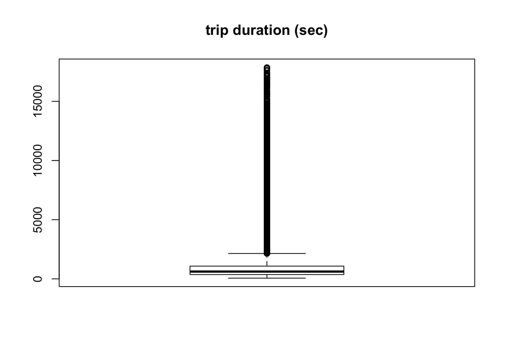

```r
#1. trip duration
boxplot(traindata$tripduration, main = "trip duration (sec)")
```

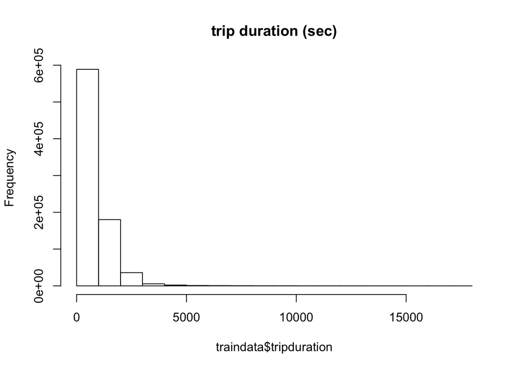

```r
hist(traindata$tripduration, main = "trip duration (sec)")
```

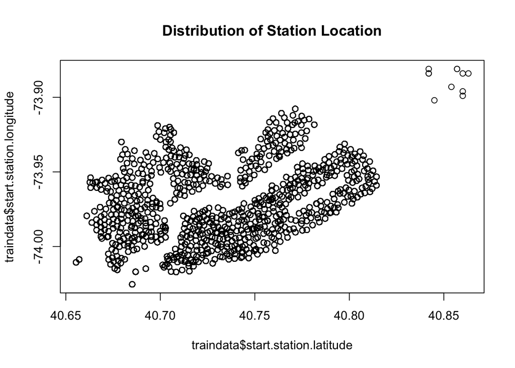

```r
#2. start/end station latitude/longitude
plot(traindata$start.station.latitude, traindata$start.station.longitude, main = "Distribution of Station Location")
```

```r
summary(traindata$start.station.latitude)
```

```
##    Min. 1st Qu.  Median    Mean 3rd Qu.    Max.
##   40.66   40.72   40.74   40.74   40.76   40.86
```

```r
summary(traindata$start.station.longitude)
```

```
##    Min. 1st Qu.  Median    Mean 3rd Qu.    Max.
##  -74.03  -74.00  -73.99  -73.98  -73.97  -73.88
```

```r
#3. how many bikes are there?
length(unique(traindata$bikeid))
```

```
## [1] 19395
```

```r
#4. how many unknown genders are there?
summary(factor(traindata$gender))
```

```
##      0      1      2
##  61349 557867 196719
```

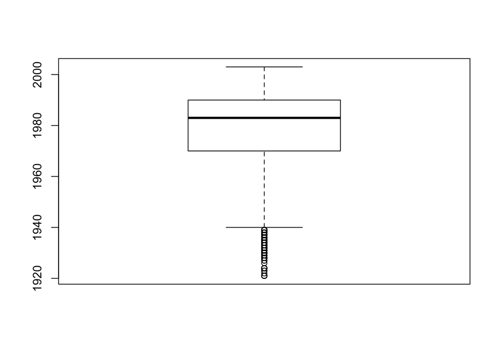

```r
#5. birth year
boxplot(traindata$birth.year)
```

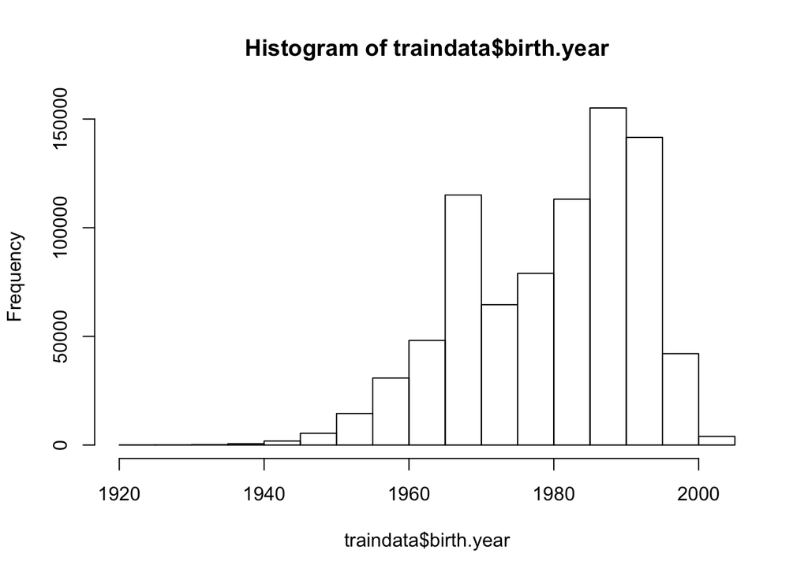

```r
hist(traindata$birth.year)
```

```r
#6. user type
summary(traindata$usertype)
```

```
##   Customer Subscriber
##     113649     702286
```

```r
#7. how many stations are known for station capacity
#summary(traindata$start.station.capacity)
#length(traindata_start_station_id_with_unknown_capacity)/length(unique(traindata$start.station.id))
#summary(traindata$end.station.capacity)
#length(traindata_end_station_id_with_unknown_capacity)/length(unique(traindata$end.station.id))
```

# 8 Data Preparation for Modeling

## 8.1 Table with per day

```r
library(plyr)

daily_study_start <- ddply(traindata,.(traindata$start_mth,traindata$start_day, Ave.Wind.Speed,TMIN...C. ,TMAX...C. ,  PRCP..mm. , SNOW..mm.), c(function(x) mean(x$birth.year),function(x) mean(x$tripduration), nrow))
colnames(daily_study_start) = c("start_month","start_day","avg_wind_speed","TMIN","TMAX","PRCP","SNOW","avg_birth_year_start","avg_trip_duration_start","total_frequency_start")

daily_study_stop <- ddply(traindata,.(traindata$stop_mth,traindata$stop_day), c(function(x) mean(x$birth.year),function(x) mean(x$tripduration), nrow))
colnames(daily_study_stop) = c("stop_month","stop_day","avg_birth_year_stop","avg_trip_duration_stop","total_frequency_stop")

daily_study = daily_study_start
daily_study$stop_month = daily_study$start_month
daily_study$stop_day = daily_study$start_day
daily_study$avg_birth_year_stop = daily_study_stop$avg_birth_year_stop
daily_study$avg_trip_duration_stop = daily_study_stop$avg_trip_duration_stop
daily_study$total_frequency_stop = daily_study_stop$total_frequency_stop

str(daily_study)
```

```
## 'data.frame':    365 obs. of  15 variables:
##  $ start_month            : int  1 1 1 1 1 1 1 1 1 1 ...
##  $ start_day              : int  1 2 3 4 5 6 7 8 9 10 ...
##  $ avg_wind_speed         : num  0 0 0 0 0 0 0 0 0 0 ...
##  $ TMIN                   : num  3.9 1.7 2.8 1.7 5 -0.5 -3.8 1.1 1.1 -2.1 ...
##  $ TMAX                   : num  14.4 4.4 6.7 8.3 8.3 9.4 1.1 7.2 7.2 1.1 ...
##  $ PRCP                   : num  1.5 0 0 0 12.7 0 0 4.3 1.5 0 ...
##  $ SNOW                   : num  0 0 0 0 0 0 0 0 0 0 ...
##  $ avg_birth_year_start   : num  1978 1979 1978 1978 1981 ...
##  $ avg_trip_duration_start: num  916 719 697 713 662 ...
##  $ total_frequency_start  : num  921 1494 1657 1747 696 ...
##  $ stop_month             : int  1 1 1 1 1 1 1 1 1 1 ...
##  $ stop_day               : int  1 2 3 4 5 6 7 8 9 10 ...
##  $ avg_birth_year_stop    : num  1978 1979 1978 1978 1980 ...
##  $ avg_trip_duration_stop : num  917 719 696 711 670 ...
##  $ total_frequency_stop   : num  919 1496 1655 1743 698 ...
```

```r
#library(plyr)
#daily_study <- ddply(traindata,.(traindata$start_mth,traindata$start_day,traindata$birth.year , Ave.Wind.Speed,TMIN...C. ,TMAX...C. ,  PRCP..mm. , SNOW..mm.),nrow)
#str(daily_study)
```

## 8.2 Table with per start station

```r
#library(plyr)
#study2 <- ddply(traindata,.(traindata$start.station.id),nrow)
#str(study2)
```

## 8.3 Table with per end station

```r
#library(plyr)
#study3 <- ddply(traindata,.(traindata$end.station.id),nrow)
#str(study3)
```

## 8.4 Table with per day and per station

```r
#library(plyr)
#daily_study_2 <- ddply(traindata,.(traindata$start.station.id,traindata$start_mth,traindata$start_day,Ave.Wind.Speed,TMIN...C. ,TMAX...C. ,  PRCP..mm. , SNOW..mm.),nrow)
#str(daily_study_2)
```

# 9 Modeling

## 9.1 Linear Model 1: Total frequency start

```r
#Linear model
#model1 <- lm(total_frequency_start ~ avg_wind_speed + TMIN + TMAX + PRCP + SNOW , data = daily_study)
model1 <- lm(total_frequency_start ~  TMAX + PRCP, data = daily_study)
summary(model1)
```

```
##
## Call:
## lm(formula = total_frequency_start ~ TMAX + PRCP, data = daily_study)
##
## Residuals:
##      Min       1Q   Median       3Q      Max
## -1639.71  -266.53    55.09   278.97  1002.85
##
## Coefficients:
##             Estimate Std. Error t value Pr(>|t|)
## (Intercept) 1206.569     46.147   26.15   <2e-16 ***
## TMAX          68.347      2.274   30.05   <2e-16 ***
## PRCP         -36.655      2.865  -12.79   <2e-16 ***
## ---
## Signif. codes:  0 '***' 0.001 '**' 0.01 '*' 0.05 '.' 0.1 ' ' 1
##
## Residual standard error: 439.3 on 362 degrees of freedom
## Multiple R-squared:  0.7447, Adjusted R-squared:  0.7433
## F-statistic:   528 on 2 and 362 DF,  p-value: < 2.2e-16
```

## 9.2 Linear Model 2: Trip duration

```r
#Linear model
#model2 <- lm(avg_trip_duration_start ~ avg_wind_speed + TMIN + TMAX + PRCP + SNOW , data = daily_study)
model2 <- lm(avg_trip_duration_start ~ TMAX + PRCP , data = daily_study)
summary(model2)
```

```
##
## Call:
## lm(formula = avg_trip_duration_start ~ TMAX + PRCP, data = daily_study)
##
## Residuals:
##     Min      1Q  Median      3Q     Max
## -186.61  -53.72  -21.59   28.05  276.25
##
## Coefficients:
##             Estimate Std. Error t value Pr(>|t|)
## (Intercept) 658.2329     8.9489  73.554  < 2e-16 ***
## TMAX          9.2791     0.4410  21.041  < 2e-16 ***
## PRCP         -3.6420     0.5556  -6.555 1.92e-10 ***
## ---
## Signif. codes:  0 '***' 0.001 '**' 0.01 '*' 0.05 '.' 0.1 ' ' 1
##
## Residual standard error: 85.19 on 362 degrees of freedom
## Multiple R-squared:  0.571,  Adjusted R-squared:  0.5686
## F-statistic: 240.9 on 2 and 362 DF,  p-value: < 2.2e-16
```

## 9.3 Linear Model 3: Birth year

```r
#Linear model
#model3 <- lm(avg_birth_year_start ~ avg_wind_speed + TMIN + TMAX + PRCP + SNOW , data = daily_study)
model3 <- lm(avg_birth_year_start ~ avg_wind_speed + TMIN, data = daily_study)
summary(model3)
```

```
##
## Call:
## lm(formula = avg_birth_year_start ~ avg_wind_speed + TMIN, data = daily_study)
##
## Residuals:
##     Min      1Q  Median      3Q     Max
## -2.1082 -0.4309 -0.0573  0.4005  2.6385
##
## Coefficients:
##                 Estimate Std. Error   t value Pr(>|t|)
## (Intercept)    1.979e+03  6.615e-02 29923.480  < 2e-16 ***
## avg_wind_speed 1.142e-01  2.956e-02     3.864 0.000132 ***
## TMIN           5.720e-02  3.837e-03    14.909  < 2e-16 ***
## ---
## Signif. codes:  0 '***' 0.001 '**' 0.01 '*' 0.05 '.' 0.1 ' ' 1
##
## Residual standard error: 0.6687 on 362 degrees of freedom
## Multiple R-squared:  0.4229, Adjusted R-squared:  0.4197
## F-statistic: 132.6 on 2 and 362 DF,  p-value: < 2.2e-16
```

## 9.4 Logistic Regression Model 4: Total frequency start

```r
#Logistic regression model

#library(mlogit)
#model4 = glm(total_frequency_start ~ avg_wind_speed + TMIN + TMAX + PRCP + SNOW , data = daily_study)
#model4 = mlogit(total_frequency_start ~ TMAX + PRCP, data = daily_study)
#summary(model4)

## CIs using standard errors
#confint.default(model4)
```

```r
#Decision tree

daily_study$total_frequency_start <- as.factor(daily_study$total_frequency_start)
library(C50)
model5 <- C5.0(daily_study[-c(10 ,15)], daily_study$total_frequency_start)
model5
```

```
##
## Call:
## C5.0.default(x = daily_study[-c(10, 15)], y = daily_study$total_frequency_start)
##
## Classification Tree
## Number of samples: 365
## Number of predictors: 13
##
## Tree size: 146
##
## Non-standard options: attempt to group attributes
```

```r
summary(model5)
```

```
##
## Call:
## C5.0.default(x = daily_study[-c(10, 15)], y = daily_study$total_frequency_start)
##
##
## C5.0 [Release 2.07 GPL Edition]      Fri Apr 17 10:09:08 2020
## -------------------------------
##
## Class specified by attribute `outcome'
##
## Read 365 cases (14 attributes) from undefined.data
##
## Decision tree:
##
## start_month > 6:
## :...start_month <= 9:
## :   :...avg_wind_speed <= 1.5:
## :   :   :...start_month > 7: 3256 (24/22)
## :   :   :   start_month <= 7:
## :   :   :   :...avg_wind_speed <= 1.2:
## :   :   :       :...avg_wind_speed <= 1.1:
## :   :   :       :   :...avg_wind_speed <= 0.9: 2981 (3/2)
## :   :   :       :   :   avg_wind_speed > 0.9: 3083 (2/1)
## :   :   :       :   avg_wind_speed > 1.1:
## :   :   :       :   :...start_day <= 8: 2146 (2/1)
## :   :   :       :       start_day > 8: 2114 (2/1)
## :   :   :       avg_wind_speed > 1.2:
## :   :   :       :...avg_wind_speed > 1.4: 2054 (2/1)
## :   :   :           avg_wind_speed <= 1.4:
## :   :   :           :...PRCP > 0: 2555 (2/1)
## :   :   :               PRCP <= 0:
## :   :   :               :...start_day <= 15: 2321 (2/1)
## :   :   :                   start_day > 15: 2923 (2/1)
## :   :   avg_wind_speed > 1.5:
## :   :   :...start_month > 8:
## :   :       :...start_day <= 15:
## :   :       :   :...PRCP > 0: 2211 (3/2)
## :   :       :   :   PRCP <= 0:
## :   :       :   :   :...avg_wind_speed <= 2.1: 2499 (3/2)
## :   :       :   :       avg_wind_speed > 2.1: 3483 (3/2)
```

[output cut: 631 more lines]

```
##  100.00% start_month
##   69.59% PRCP
##   56.16% avg_wind_speed
##   50.41% start_day
##   41.10% TMIN
##   20.27% TMAX
##    9.32% SNOW
##    7.95% avg_birth_year_stop
##    7.40% avg_trip_duration_start
##    4.93% avg_birth_year_start
##    2.74% stop_day
##    2.47% avg_trip_duration_stop
##
##
## Time: 0.1 secs
```

```r
#plot(model5)
```

# 10 Organize Data Again

```r
#install.packages("plyr")
#library("plyr")

#entire_2019_refined_per_station = ddply(traindata,. (traindata$start_year, traindata$start_mth,  traindata$start.station.id, traindata$tripduration, traindata$usertype, traindata$birth.year, traindata$TMIN...C., traindata$TMAX...C., traindata$Ave.Wind.Speed, traindata$PRCP..mm., traindata$SNOW..mm. ), nrow)

#entire_2019_refined_per_station = ddply(traindata,. (traindata$start_year, traindata$start_mth, traindata$start_day, traindata$start.station.id, traindata$tripduration, traindata$usertype, traindata$birth.year, traindata$TMIN...C., traindata$TMAX...C., traindata$Ave.Wind.Speed, traindata$PRCP..mm., traindata$SNOW..mm. ), nrow)

#rename columns
#colnames(entire_2019_refined_per_day) = c("start_year","start_month","start_day","TMIN_C","TMAX_C","WindSpeed","PRCP_mm","SNOW_mm","Freq")
#colnames(entire_2019_refined_per_station) = c("start_year","start_month","start_day","start_station","TMIN_C","TMAX_C","WindSpeed","PRCP_mm","SNOW_mm","Freq")
```

# 11 Model

1. Linear Regression
2. Logistic Regression
3. KNN
4. ANN
5. SVM
6. Decision Trees
7. Random Forest

```r
#linear regression
#lm_per_station = lm(Freq ~ ., data = entire_2019_refined_per_station)
#summary(lm_per_station)

#logistic regression
#logis_per_station = glm(Freq ~ ., data = entire_2019_refined_per_station)
#summary(logis_per_station)
```

# 12 Data Preparation for 5% Testing

## 12.1 Table with per day

```r
library(plyr)

daily_test_start <- ddply(testdata,.(testdata$start_mth,testdata$start_day, Ave.Wind.Speed,TMIN...C. ,TMAX...C. ,  PRCP..mm. , SNOW..mm.), c(function(x) mean(x$birth.year),function(x) mean(x$tripduration), nrow))
colnames(daily_test_start) = c("start_month","start_day","avg_wind_speed","TMIN","TMAX","PRCP","SNOW","avg_birth_year_start","avg_trip_duration_start","total_frequency_start")

daily_test_stop <- ddply(testdata,.(testdata$stop_mth,testdata$stop_day), c(function(x) mean(x$birth.year),function(x) mean(x$tripduration), nrow))
colnames(daily_test_stop) = c("stop_month","stop_day","avg_birth_year_stop","avg_trip_duration_stop","total_frequency_stop")

daily_test = daily_test_start
daily_test$stop_month = daily_test$start_month
daily_test$stop_day = daily_test$start_day
daily_test$avg_birth_year_stop = daily_test_stop$avg_birth_year_stop
daily_test$avg_trip_duration_stop = daily_test_stop$avg_trip_duration_stop
daily_test$total_frequency_stop = daily_test_stop$total_frequency_stop

head(daily_test)
```

```
##   start_month start_day avg_wind_speed TMIN TMAX PRCP SNOW avg_birth_year_start
## 1           1         1              0  3.9 14.4  1.5    0             1978.819
## 2           1         2              0  1.7  4.4  0.0    0             1978.008
## 3           1         3              0  2.8  6.7  0.0    0             1978.061
## 4           1         4              0  1.7  8.3  0.0    0             1979.776
## 5           1         5              0  5.0  8.3 12.7    0             1980.760
## 6           1         6              0 -0.5  9.4  0.0    0             1980.304
##   avg_trip_duration_start total_frequency_start stop_month stop_day
## 1               1024.1395                   215          1        1
## 2                748.7204                   372          1        2
## 3                740.5956                   408          1        3
## 4                752.9736                   416          1        4
## 5                592.4800                   150          1        5
## 6                690.0092                   326          1        6
##   avg_birth_year_stop avg_trip_duration_stop total_frequency_stop
## 1            1978.819              1024.1395                  215
## 2            1978.008               748.7204                  372
## 3            1978.079               741.2285                  407
## 4            1979.742               752.6964                  415
## 5            1980.783               593.5724                  152
## 6            1980.304               690.0092                  326
```

# 13 Test 5% data

## 13.1 Model 1

```r
#Linear regression

usagePred <- predict(model1, daily_test)

actuals_preds <- data.frame(cbind(actuals=daily_test$total_frequency_start, predicteds=usagePred))  # make actuals_predicteds dataframe
correlation_accuracy <- cor(actuals_preds)
head(actuals_preds)
```

```
##   actuals predicteds
## 1     215   2135.784
## 2     372   1507.296
## 3     408   1664.494
## 4     416   1773.849
## 5     150   1308.332
## 6     326   1849.031
```

```r
correlation_accuracy
```

```
##              actuals predicteds
## actuals    1.0000000  0.8562807
## predicteds 0.8562807  1.0000000
```

```r
min_max_accuracy <- mean(apply(actuals_preds, 1, min) / apply(actuals_preds, 1, max))
# min_max accuracy
mape <- mean(abs((actuals_preds$predicteds - actuals_preds$actuals))/actuals_preds$actuals)
# mean absolute percentage deviation
min_max_accuracy
```

```
## [1] 0.2495905
```

```r
mape
```

```
## [1] 3.276344
```

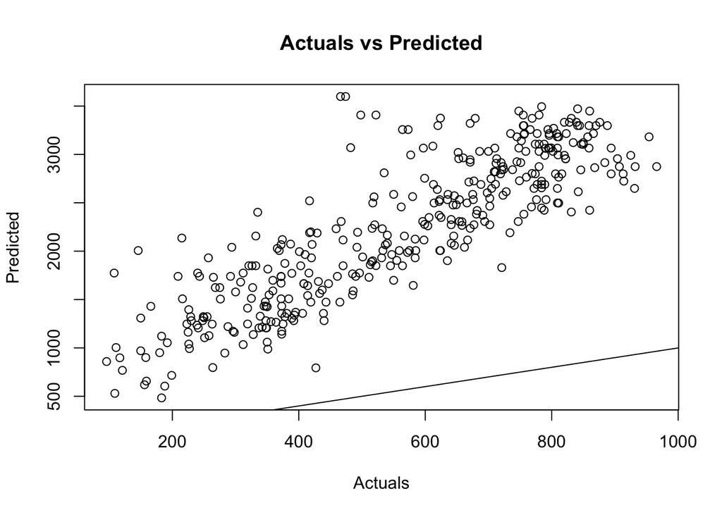

```r
plot(actuals_preds$actuals,actuals_preds$predicteds, main = "Actuals vs Predicted",
     xlab = "Actuals" , ylab = "Predicted")
abline(a = 0, b = 1)
```

## 13.2 Model 2

```r
#Linear regression

tripPred <- predict(model2, daily_test)

actuals_preds <- data.frame(cbind(actuals=daily_test$avg_trip_duration_start, predicteds=tripPred))  # make actuals_predicteds dataframe
correlation_accuracy <- cor(actuals_preds)
head(actuals_preds)
```

```
##     actuals predicteds
## 1 1024.1395   786.3896
## 2  748.7204   699.0612
## 3  740.5956   720.4032
## 4  752.9736   735.2498
## 5  592.4800   688.9967
## 6  690.0092   745.4568
```

```r
correlation_accuracy
```

```
##              actuals predicteds
## actuals    1.0000000  0.7208245
## predicteds 0.7208245  1.0000000
```

```r
min_max_accuracy <- mean(apply(actuals_preds, 1, min) / apply(actuals_preds, 1, max))
# min_max accuracy
mape <- mean(abs((actuals_preds$predicteds - actuals_preds$actuals))/actuals_preds$actuals)
# mean absolute percentage deviation
min_max_accuracy
```

```
## [1] 0.9211276
```

```r
mape
```

```
## [1] 0.08377919
```

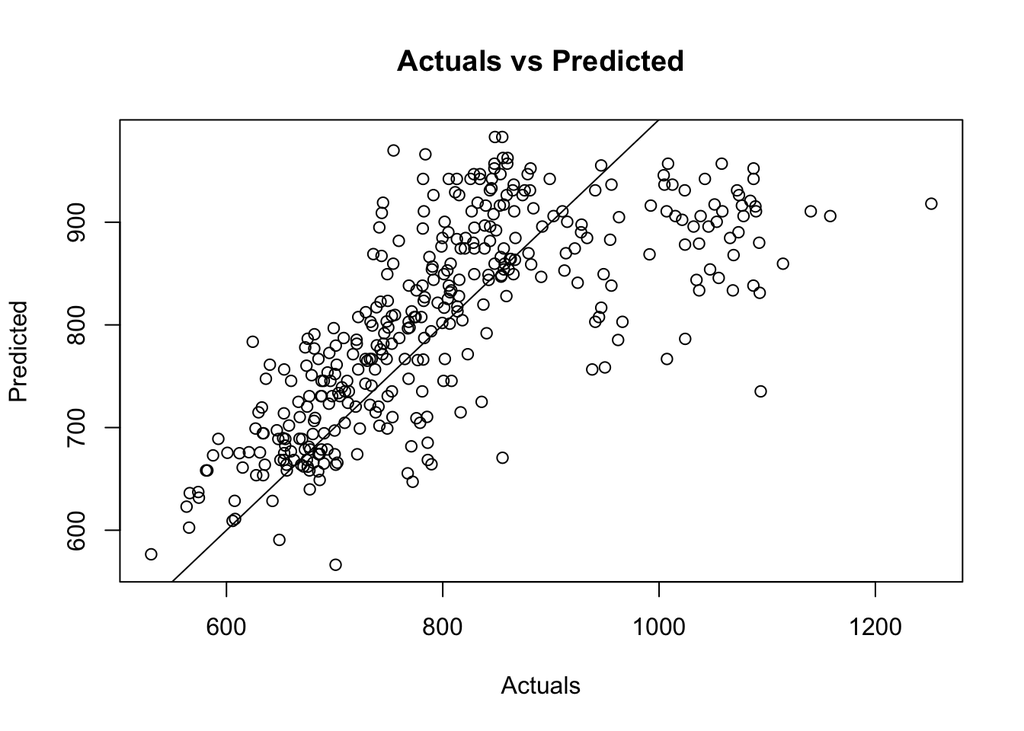

```r
plot(actuals_preds$actuals,actuals_preds$predicteds, main = "Actuals vs Predicted",
     xlab = "Actuals" , ylab = "Predicted")
abline(a = 0, b = 1)
```

## 13.3 Model 3

```r
#Linear regression

agePred <- predict(model3, daily_test)

actuals_preds <- data.frame(cbind(actuals=daily_test$avg_birth_year_start, predicteds=agePred))  # make actuals_predicteds dataframe
correlation_accuracy <- cor(actuals_preds)
head(actuals_preds)
```

```
##    actuals predicteds
## 1 1978.819   1979.578
## 2 1978.008   1979.452
## 3 1978.061   1979.515
## 4 1979.776   1979.452
## 5 1980.760   1979.641
## 6 1980.304   1979.326
```

```r
correlation_accuracy
```

```
##              actuals predicteds
## actuals    1.0000000  0.5622554
## predicteds 0.5622554  1.0000000
```

```r
min_max_accuracy <- mean(apply(actuals_preds, 1, min) / apply(actuals_preds, 1, max))
# min_max accuracy
mape <- mean(abs((actuals_preds$predicteds - actuals_preds$actuals))/actuals_preds$actuals)
# mean absolute percentage deviation
min_max_accuracy
```

```
## [1] 0.9996754
```

```r
mape
```

```
## [1] 0.0003247431
```

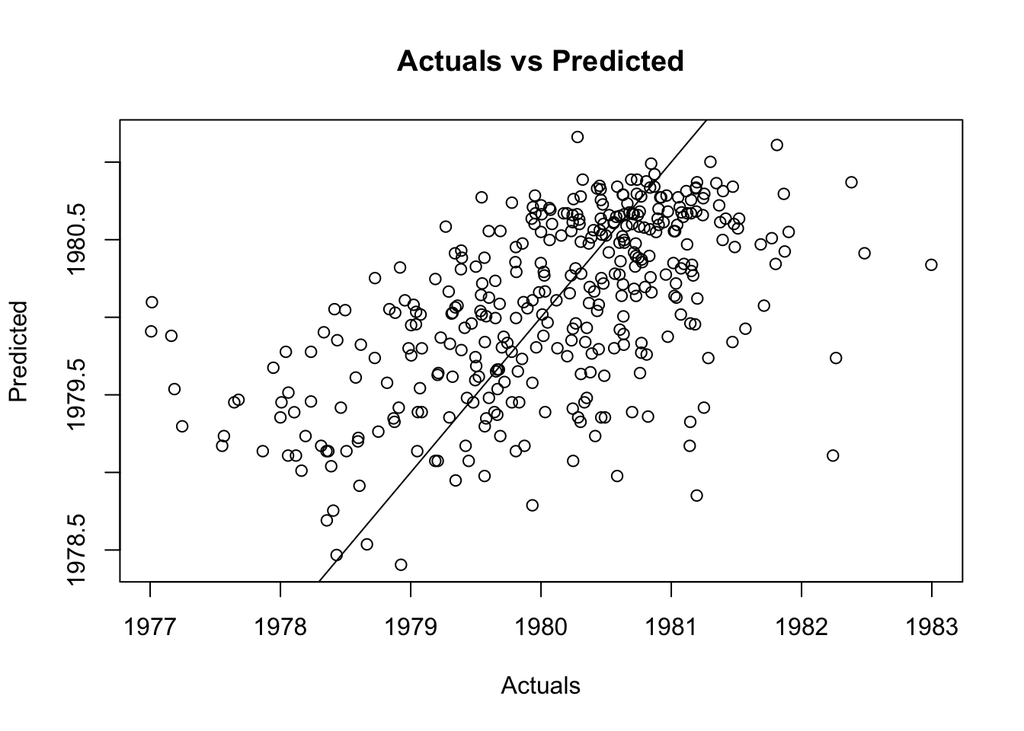

```r
plot(actuals_preds$actuals,actuals_preds$predicteds, main = "Actuals vs Predicted",
     xlab = "Actuals" , ylab = "Predicted")
abline(a = 0, b = 1)
```

## 13.4 Model 4

```r
#Logistic regression

#usagePred <- predict(model4, newdata = daily_test, type = "response")
#head(usagePred)


#usagePred <- ifelse(usagePred > 0.5,1,0)

#misClasificError <- mean(usagePred != daily_test$total_frequency_start)
#print(paste('Accuracy',1-misClasificError))
```

## 13.5 Model 5

```r
# Decision trees

## Step 4: Evaluating model performance ----
# create a factor vector of predictions on test data
usagePred<- predict(model5, daily_test)

# cross tabulation of predicted versus actual classes
#library(gmodels)
#CrossTable(daily_test$total_frequency_start, usagePred,
#           prop.chisq = FALSE, prop.c = FALSE, prop.r = FALSE,
#           dnn = c('actual default', 'predicted default'))
daily_test$total_frequency_start <- as.factor(daily_test$total_frequency_start)
actuals_preds <- data.frame(cbind(actuals=daily_test$total_frequency_start, predicteds=usagePred))  # make actuals_predicteds dataframe
correlation_accuracy <- cor(actuals_preds)
head(actuals_preds)
```

```
##   actuals predicteds
## 1      19         10
## 2      76         90
## 3      91         90
## 4      94         52
## 5       8         10
## 6      56         52
```

```r
min_max_accuracy <- mean(apply(actuals_preds, 1, min) / apply(actuals_preds, 1, max))
# min_max accuracy
mape <- mean(abs((actuals_preds$predicteds - actuals_preds$actuals))/actuals_preds$actuals)
# mean absolute percentage deviation
min_max_accuracy
```

```
## [1] 0.7653922
```

```r
mape
```

```
## [1] 0.2959614
```

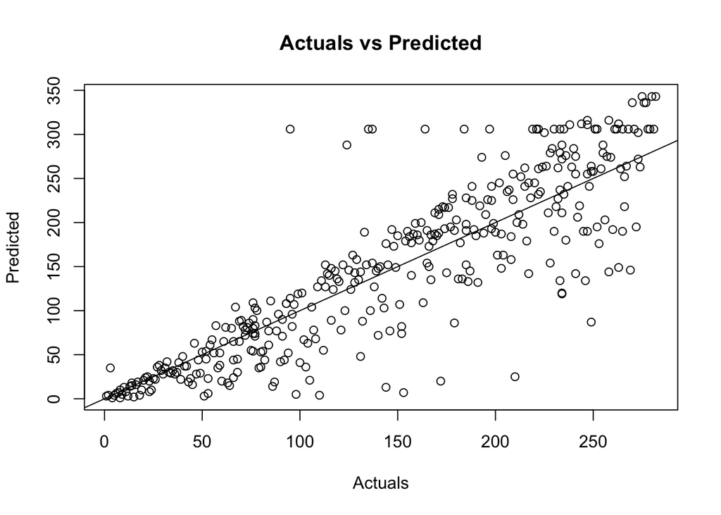

```r
plot(actuals_preds$actuals,actuals_preds$predicteds, main = "Actuals vs Predicted",
     xlab = "Actuals" , ylab = "Predicted")
abline(a = 0, b = 1)
```

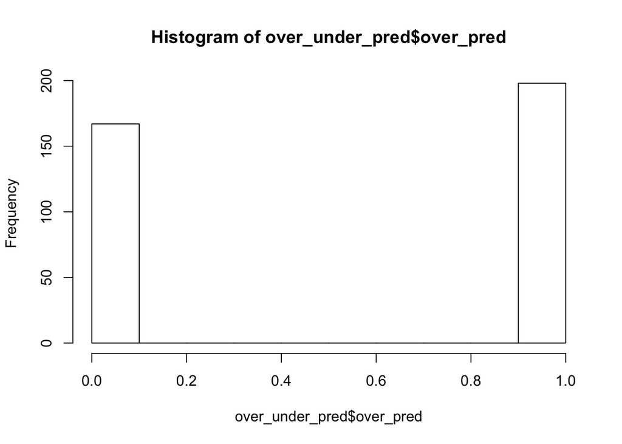

```r
# How many times do we overpredict or underpredict?
over_under_pred <- actuals_preds
over_under_pred$over_pred <- ifelse(over_under_pred$actuals<over_under_pred$predicteds,1,0)
hist(over_under_pred$over_pred)
```